# Assignment 6

## ATSC 595

## Andrew Loeppky

```python
import numpy as np
import scipy.special as sp
from matplotlib import pyplot as plt
import math
```

Use eq 2-14 (page 2-7 of Calpuff User Guide technical details) for the following slug, Given:

$$ C(t) = \frac{Fq}{(2\pi)^{1/2}u'\sigma_y}g\cdot exp\left[\frac{-d_c^2}{2\sigma_y^2}\frac{u^2}{u'^2}\right]\tag{2-14} $$$$ F = \frac{1}{2}\left\{erf\left[\frac{d_{a2}}{\sqrt{2}\sigma_{y2}}\right] - erf\left[\frac{-d_{a1}}{\sqrt{2}\sigma_{y1}}\right]\right\}\tag{2-15} $$$$ g = \frac{2}{(2\pi)^{1/2}\sigma_z}\sum_{n=-\infty}^\infty exp\left[-(H_e + 2nh)^2 / (2\sigma_z^2)\right]\tag{2-2} $$

Mean wind:

$$ U = 8 m/s, V = 6 m/s $$

The length of the main body of the slug is $u \Delta t_e$, where $u$ is the wind speed and $\Delta t_e$ is the time of emission of the pollutant.

```
Slug initial point emitted 20 minutes ago.
Slug final point emitted 15 minutes ago.
```

Emission rate of pollutant:

$$ q = 500 g/s $$

Source height:

$$ H_s = 50 m $$

All receptors are at the surface, z = 0. with $t_L = 60 s$, $\sigma_v = 1 m/s$ and $\sigma_w = 2 m/s$. Boundary layer depth = constant = h = $1 km$.

Crosswind spread $\sigma_y$: given by Stull eq. (19.13a):

$$ \sigma_y^2 = 2\cdot \sigma_v^2\cdot t_L^2 \left[\frac{x}{M\cdot t_L} - 1 + exp\left(\frac{-x}{M\cdot t_L}\right)\right]\tag{Stull 19.13a} $$

Vertical spread $\sigma_z$: given by Stull eq. (19.13b):

$$ \sigma_z^2 = 2\cdot \sigma_w^2\cdot t_L^2 \left[\frac{x}{M\cdot t_L} - 1 + exp\left(\frac{-x}{M\cdot t_L}\right)\right]\tag{Stull 19.13b} $$

```python
# givens
U = 8  # m/s
V = 6  # m/s
q = 500  # g/s
Hs = 50  # source height 50m
sigma_v = 1  # m/s
sigma_w = 2  # m/s
h = 1000  # m
tL = 60  # s
t1 = 15 * 60  # s
t2 = 20 * 60  # s

# calcs
def get_sigma(x, sigma_vel):
    """
    returns sigma given downwind distance and velocity
    variance as per stull 19.13 a/b
    """
    sigma2 = 2 * sigma_vel ** 2 * tL ** 2 * ((x / U / tL) - 1 + np.exp(-x / U / tL))
    return sigma2 ** 0.5
```

## Question 1

Plot a graph of the "causality" function F vs. downwind distance x, for the subdomain of x where F is significantly different from zero.

$$ F = \frac{1}{2}\left\{erf\left[\frac{x - d_{a2}}{\sqrt{2}\sigma_{y2}}\right] - erf\left[\frac{-(x - d_{a1})}{\sqrt{2}\sigma_{y1}}\right]\right\}\tag{2-15*} $$

```python
def get_F(t1, t2, x):
    '''
    casualty function CALPUFF (2-15)
    '''
    da1 = U * t2
    da2 = U * t1

    sigma_y1 = get_sigma(da1, sigma_v)
    sigma_y2 = get_sigma(da2, sigma_v)

    F = 0.5 * (sp.erf((x - da2) / (np.sqrt(2) * sigma_y2)) - sp.erf((x - da1) / (np.sqrt(2) * sigma_y1)))

    return F
```

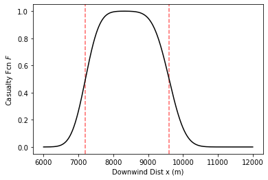

```python
x = np.linspace(6000,12000,1000)
F = get_F(t1, t2, x)

# plot result
fig, ax = plt.subplots()
ax.axvline(U * t2, linestyle="--", color="r", alpha=0.6)
ax.axvline(U * t1, linestyle="--", color="r", alpha=0.6)
ax.plot(x, F, "k")
ax.set_xlabel("Downwind Dist x (m)")
ax.set_ylabel("Casualty Fcn $F$");
```

### Discussion

*The casualty function reaches 1/2 at $d_{a1}$ and $d_{a2}$, and peaks between the two puff centers where there is maximum overlap. This makes sense, as the integral of a gaussian (error function) is 1/2 at the peak of the distribution (red dashed lines).*

## Question 2

Plot a graph of the vertical term "g" vs. height z within the boundary layer, for an x location corresponding to the middle of the slug.

$$ g = \frac{2}{(2\pi)^{1/2}\sigma_z}\sum_{n=-\infty}^\infty exp\left[-(z - (H_e + 2nh))^2 / (2\sigma_z^2)\right]\tag{2-2*} $$

```python
def get_g(x, z):
    """
    plots "g" term as defined by CALPUFF (2-2) as a function of downwind
    distance x and height z
    """
    n = np.arange(-10, 10) # this converges
    g = 0
    sigma_z = get_sigma(x, sigma_w)
    # do it in a loop so that this function can take arrays for z
    for ni in n:
        g += np.exp(-(z - (Hs + 2 * ni * h)) ** 2 / (2 * sigma_z ** 2))
    g *= (2 / np.sqrt(2 * np.pi) * sigma_z)
    return g
```

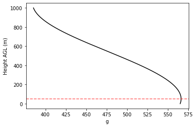

```python
mid_slug = U * (t2 + t1) / 2  # midpoint b/w da1 and da2 (m)
z = np.linspace(0, h, 1001)
gz = get_g(mid_slug, z)

# plot result
plt.plot(gz, z, color="k")
plt.axhline(Hs, color="r", linestyle="--", alpha=0.6)
plt.ylabel("Height AGL (m)")
plt.xlabel("g");
```

### Discussion

*The $H_e$ term describes the vertical spread of the plume around it's centerline (I used a flat centerline at $H_s$ -- a more realistic simulation would incorporate Deardorff's parameterizations), and the $2nh$ term accounts for multiple plume reflection. Terms $n > 1$ describe secondary reflections (think of a pollutant parcel ping-ponging off the top and bottom of the domain) and only become important after several hours (page 2-4).*

## Question 3

Draw a contour plot of instantaneous concentration $C$ at the surface, for a grid of receptors that span the region near the slug where concentration is significantly different from zero.

$$ C(t) = \frac{Fq}{(2\pi)^{1/2}u'\sigma_y}g\cdot exp\left[\frac{-d_c^2}{2\sigma_y^2}\frac{u^2}{u'^2}\right]\tag{2-14} $$$$ u' \equiv (u^2 + \sigma_v^2)^{1/2} $$

```python
def get_C(x, y, z, t1, t2):
    """
    Calculates the concentration in the vicinity of a slug using CALPUFF (2-14)
    """
    u_prime = (U ** 2 + sigma_v ** 2) ** 0.5
    term1 = (get_F(t1, t2, x) * q * get_g(x, z)) / ((2 * np.pi) ** 0.5 * u_prime * get_sigma(x, sigma_v))
    term2 = np.exp(-(y ** 2 * U ** 2) / (2 * get_sigma(x, sigma_v) ** 2 * u_prime ** 2))
    return term1 * term2
```

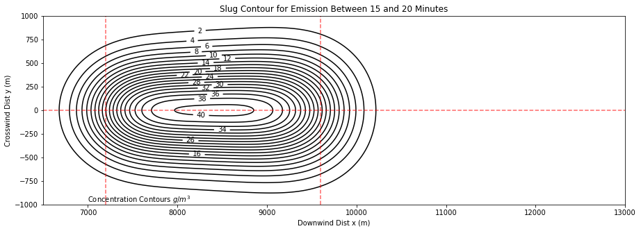

```python
# make an xy grid
x_range = np.linspace(6500,13000,1000)
y_range = np.linspace(-1000, 1000, 1000)
z = 0
receptor_grid = np.zeros((len(x_range), len(y_range)))

# fill it with values
for i, x in enumerate(y_range):
    receptor_grid[i] = get_C(x_range, y_range[i], z, t1, t2)

# plot the result
fig, ax = plt.subplots(figsize=(15,5))
con = ax.contour(x_range, y_range, receptor_grid, colors="k", levels=np.linspace(2, 40, 20))
ax.clabel(con) # label the contours
ax.axvline(U * t1, linestyle="--", color="r", alpha=0.6)
ax.axvline(U * t2, linestyle="--", color="r", alpha=0.6)
ax.axhline(0, color="r", linestyle="--", alpha=0.6)
ax.annotate("Concentration Contours $g/m^3$",(7000, -980))
ax.set_xlabel("Downwind Dist x (m)")
ax.set_ylabel("Crosswind Dist y (m)")
ax.set_title(f"Slug Contour for Emission Between {t1 // 60} and {t2 // 60} Minutes");
```

## Question 4

Draw a contour plot of instantaneous concentration $C$ at the surface for the same slug, but corresponding to a time 5 minutes later than you answer from part (3). Caution: be sure to recompute all input variables that would have changed during this time interval.

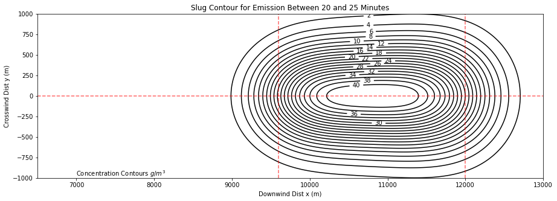

```python
# just change t1 and t2, copy and paste code from 3
t1 += 5 * 60
t2 += 5 * 60
receptor_grid = np.zeros((len(x_range), len(y_range)))

# fill it with values
for i, x in enumerate(y_range):
    receptor_grid[i] = get_C(x_range, y_range[i], z, t1, t2)

# plot the result
fig, ax = plt.subplots(figsize=(15,5))
con = ax.contour(x_range, y_range, receptor_grid, colors="k", levels=np.linspace(2, 40, 20))
ax.clabel(con) # label the contours
ax.axvline(U * t1, linestyle="--", color="r", alpha=0.6)
ax.axvline(U * t2, linestyle="--", color="r", alpha=0.6)
ax.axhline(0, color="r", linestyle="--", alpha=0.6)
ax.annotate("Concentration Contours $g/m^3$",(7000, -980))
ax.set_xlabel("Downwind Dist x (m)")
ax.set_ylabel("Crosswind Dist y (m)")
ax.set_title(f"Slug Contour for Emission Between {t1 // 60} and {t2 // 60} Minutes");
```

### Discussion

*We see the slug has moved downwind and spread out, as expected*

## Question 5

Numerically integrate to get a contour plot of 5-minute time average concentration for the slug that moved from its location in exercise (3) to its location in exercise (4). Hint, start with the answer from (3), and then compute new answers at the grid points each small timestep delta_t = 10 s until you get to the final slug location from exercise (4). Accumulate the concentrations at each grid point, and then find the time average. Think carefully how the average of your many finite steps relates to a 5-minute time average of C.

```python
# set up timesteps
tstart = 15 * 60
tend = 20 * 60
dt = 10
numcalcs = (tend - tstart) // dt

# loop over all times and increment C
receptor_grid = np.zeros((len(x_range), len(y_range)))
for t1 in np.arange(tstart, tend, dt):
    t2 = t1 + 5 * 60
    for i, x in enumerate(y_range):
        receptor_grid[i] += get_C(x_range, y_range[i], z, t1, t2) / numcalcs
```

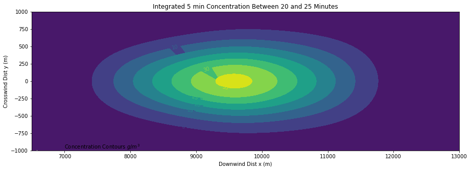

```python
# plot result
fig, ax = plt.subplots(figsize=(15,5))
con = ax.contourf(x_range, y_range, receptor_grid)#, colors="k", levels=np.linspace(2, 40, 20))
ax.clabel(con) # label the contours
ax.annotate("Concentration Contours $g/m^3$",(7000, -980))
ax.set_xlabel("Downwind Dist x (m)")
ax.set_ylabel("Crosswind Dist y (m)")
ax.set_title(f"Integrated 5 min Concentration Between {round(t1 / 60)} and {round(t2 / 60)} Minutes");
```

### (5a)

Would your answer change if you used a smaller timestep?

> *Let's see!*

```python
# set up smaler timesteps
tstart = 15 * 60
tend = 20 * 60
dt = 2  # smaller timestep

# keep all this the same but call the new concentration grid a new name
numcalcs = (tend - tstart) // dt
receptor_grid2 = np.zeros((len(x_range), len(y_range)))
for t1 in np.arange(tstart, tend, dt):
    t2 = t1 + 5 * 60
    for i, x in enumerate(y_range):
        receptor_grid2[i] += get_C(x_range, y_range[i], z, t1, t2) / numcalcs
```

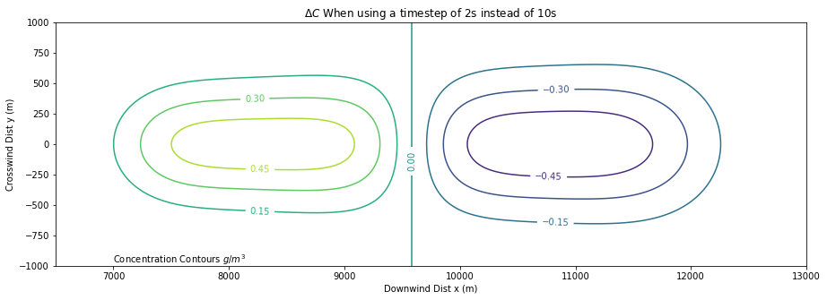

```python
# plot the difference between the original (dt=10) and new (dt=2) simulations
fig, ax = plt.subplots(figsize=(15,5))
con = ax.contour(x_range, y_range, receptor_grid - receptor_grid2)#, colors="k", levels=np.linspace(2, 40, 20))
ax.clabel(con) # label the contours
ax.annotate("Concentration Contours $g/m^3$",(7000, -980))
ax.set_xlabel("Downwind Dist x (m)")
ax.set_ylabel("Crosswind Dist y (m)")
ax.set_title(f"$\Delta C$ When using a timestep of 2s instead of 10s");
```

*We see here that larger timesteps tend to overestimate the concentration near the source, and underestimate it farther downwind. The magnitudes here are of order 1\%, which is small in this context*

### (5b)

Also, how small of a timestep is small enough, and how do you know?

```python
# set up smaler timesteps
tstart = 15 * 60
tend = 20 * 60
receptor_dict = {} # store all the concentration fields in a dictionary

for dt in [10, 20, 60, 120, 240]:  # smaller timestep
    numcalcs = (tend - tstart) // dt
    receptor_dict[f"dt={dt}"] = np.zeros((len(x_range), len(y_range)))
    for t1 in np.arange(tstart, tend, dt):
        t2 = t1 + 5 * 60
        for i, x in enumerate(y_range):
            receptor_dict[f"dt={dt}"] += get_C(x_range, y_range[i], z, t1, t2) / numcalcs
```

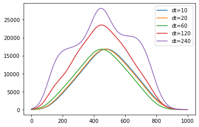

```python
# plot an arbirarily chosen slice for each run
for key in receptor_dict.keys():
    my_slice = receptor_dict[key][500]
    plt.plot(my_slice, label=key)
plt.legend();
```

### Discussion

*The concentration at this location appears to converge at $dt \approx 20s$. The timestep needs to be small enough to resolve the slug as it passes -- in this case timesteps > 5min would miss the slug entirely and report concentrations very close to the background. Large of timesteps over-estimate the concentration by only sampling near the peak, as we see here. They might in principle also underestimate $C$ by only sampling the head and tail of the slug and missing the peak entirely.*

## Question 6

Discuss the meaning of your answers from all the previous exercises.

*See discussion embedded in each individual question*